# Reproducible Research: Peer Assessment 1

## Environment Settings

Not all packages are in one chunk code due to conflicts with lubridate either with VIM, mice or misforest package.

```r
library(tidyverse)
library(reshape2)
library(lubridate)
library(gt)
library(glue)
library(paletteer)
library(scales)
```

## Load Datasets

```r
fileUrl <- "https://d396qusza40orc.cloudfront.net/repdata%2Fdata%2Factivity.zip"
fname <- c("./data/pamd.zip")

source("LoadUnzip.R")
dateDownloaded
# LoadUnzip.R = if(!file.exists("data")){
#         dir.create("data")
# }
#
# download.file(fileUrl,destfile="./data/pamd.zip",method="curl")
#
# dateDownloaded <- date()
#
# maindf <- read_delim(fname, delim = ",", col_names = TRUE)
```

Dataset download date Thu Apr 16 19:07:09 2020.

Range of Date

```r
start_date <- min(maindf$date)
end_date <- max(maindf$date)
range(maindf$date)
```

```
## [1] "2012-10-01" "2012-11-30"
```

## What is **mean** total number of steps taken per day?

For this part of the assignment, you can ignore the missing values in the dataset.

1. Calculate the total number of steps taken per day? Answer: MeanTotal gives us the breakdown of steps each day.
2. If you do not understand the difference between a histogram and a barplot, research the difference between them. Make a histogram of the total number of steps taken each day
3. Calculate and report the mean and median of the total number of steps taken per day

GTMeanTotal is using the (gt) grammar for tables, scale, glue, and paletteer package. The yellow hightlighted portion gives as the Total steps - mean and median for 53 observations (I used *drop_na* from dplyr package to remove the NA).

```r
MeanTotal <- maindf %>% drop_na() %>% group_by(date) %>%  summarize(Steps = sum(steps)) %>% mutate(m=month(date))
head(MeanTotal)
```

```
## # A tibble: 6 x 3
##   date       Steps     m
##   <date>     <dbl> <dbl>
## 1 2012-10-02   126    10
## 2 2012-10-03 11352    10
## 3 2012-10-04 12116    10
## 4 2012-10-05 13294    10
## 5 2012-10-06 15420    10
## 6 2012-10-07 11015    10
```

Mean and Median

```r
StepsMeanMed <- MeanTotal %>% summarize(Obs = length(date), SumofSteps = sum(Steps), StepsMean = mean(Steps), StepsMedian = median(Steps) )

GTMeanTotal <- StepsMeanMed %>% gt::gt() %>% data_color(
        columns = vars(Obs,SumofSteps, StepsMean,StepsMedian),
        colors = c("yellow")) %>%
        tab_header(title = "Step Mean and Median Summary",
        subtitle = glue("{start_date} to {end_date}"))

GTMeanTotal
```

Step Mean and Median Summary

2012-10-01 to 2012-11-30

| Obs | SumofSteps | StepsMean | StepsMedian |
| --- | --- | --- | --- |
| 53 | 570608 | 10766.19 | 10765 |

### Histogram of Steps taken Each Day

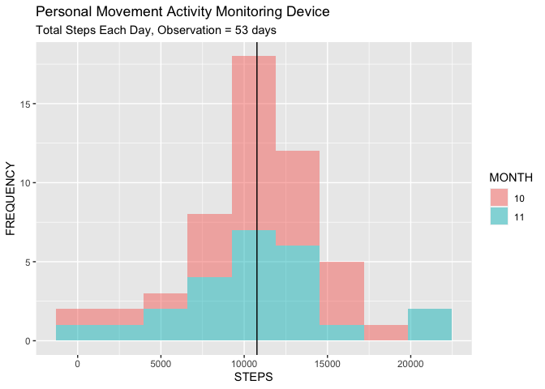

```r
g1<-ggplot(data = MeanTotal, aes(x=Steps,fill=factor(m)))
gg1 <- g1+geom_histogram(bins = 9, alpha=.5)+geom_vline(xintercept = mean(MeanTotal$Steps))+
  labs(title="Personal Movement Activity Monitoring Device",
         subtitle="Total Steps Each Day, Observation = 53 days",
         x="STEPS",
         y="FREQUENCY",
         fill="MONTH")
gg1
```

## What is the average daily activity pattern?

I’m using the gt (grammar for tables) package to analyze the average of steps in 5 minute interval. This table has 288 observations - see below:.

```r
SummaryIntervalSteps <- maindf %>% drop_na() %>% group_by(TimeInterval=interval)%>%
        summarize(Total_Obs = length(interval),
        SumOfSteps = sum(steps),
        MeanOfSteps = mean(steps))

GTInterval <- SummaryIntervalSteps %>% gt::gt() %>% data_color(
    columns = vars(SumOfSteps, MeanOfSteps),
    colors = scales::col_numeric(
      palette = paletteer::paletteer_d(
        palette = "ggsci::red_material"
        ) %>% as.character(),
      domain = NULL
      )
  ) %>% tab_header(title = "Personal Movement Activity Monitoring Device",
        subtitle = glue("{start_date} to {end_date}"))

GTInterval
```

Personal Movement Activity Monitoring Device

2012-10-01 to 2012-11-30

| TimeInterval | Total_Obs | SumOfSteps | MeanOfSteps |
| --- | --- | --- | --- |
| 0 | 53 | 91 | 1.7169811 |
| 5 | 53 | 18 | 0.3396226 |
| 10 | 53 | 7 | 0.1320755 |
| 15 | 53 | 8 | 0.1509434 |
| 20 | 53 | 4 | 0.0754717 |
| 25 | 53 | 111 | 2.0943396 |
| 30 | 53 | 28 | 0.5283019 |
| 35 | 53 | 46 | 0.8679245 |
| 40 | 53 | 0 | 0.0000000 |
| 45 | 53 | 78 | 1.4716981 |
| 50 | 53 | 16 | 0.3018868 |
| 55 | 53 | 7 | 0.1320755 |
| 100 | 53 | 17 | 0.3207547 |
| 105 | 53 | 36 | 0.6792453 |
| 110 | 53 | 8 | 0.1509434 |
| 115 | 53 | 18 | 0.3396226 |
| 120 | 53 | 0 | 0.0000000 |
| 125 | 53 | 59 | 1.1132075 |
| 130 | 53 | 97 | 1.8301887 |
| 135 | 53 | 9 | 0.1698113 |
| 140 | 53 | 9 | 0.1698113 |
| 145 | 53 | 20 | 0.3773585 |
| 150 | 53 | 14 | 0.2641509 |
| 155 | 53 | 0 | 0.0000000 |
| 200 | 53 | 0 | 0.0000000 |
| 205 | 53 | 0 | 0.0000000 |
| 210 | 53 | 60 | 1.1320755 |
| 215 | 53 | 0 | 0.0000000 |
| 220 | 53 | 0 | 0.0000000 |
| 225 | 53 | 7 | 0.1320755 |

[output cut: 258 more lines]

###Timeseries 1. Make a time series plot (i.e. type=“l”) of the 5-minute interval (x-axis) and the average number of steps taken, averaged across all days (y-axis)

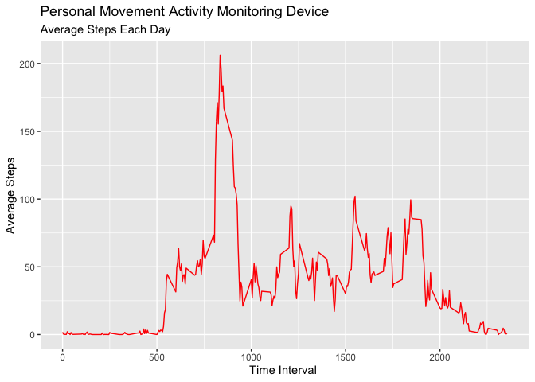

```r
g2<-ggplot(data = SummaryIntervalSteps, aes(y=MeanOfSteps, x=TimeInterval))
g2+geom_line(color="red")+
        labs(title="Personal Movement Activity Monitoring Device",
         subtitle="Average Steps Each Day",
         x="Time Interval ",
         y="Average Steps",
         fill="MONTH")
```

2. Which 5-minute interval, on average across all the days in the dataset, contains the maximum number of steps? 8:35 a.m.

```r
SummaryIntervalSteps %>%  filter(MeanOfSteps==max(MeanOfSteps)) %>% select(TimeInterval, MeanOfSteps)
```

```
## # A tibble: 1 x 2
##   TimeInterval MeanOfSteps
##          <dbl>       <dbl>
## 1          835        206.
```

## Imputing missing values

Note that there are a number of days/intervals where there are missing values (coded as NA). The presence of missing days may introduce bias into some calculations or summaries of the data.

1. Calculate and report the total number of missing values in the dataset (i.e. the total number of rows with NAs)
2. Devise a strategy for filling in all of the missing values in the dataset. The strategy does not need to be sophisticated. For example, you could use the mean/median for that day, or the mean for that 5-minute interval, etc.

```r
Yeardf <- maindf %>% group_by(`Year`=year(date)) %>%
        summarize(ISNA_Count = sum(is.na(steps)), Mean_ISNA=mean(is.na(steps)),
        Total_Obs = length(maindf$date)) %>% ungroup() %>% gt() %>%
        tab_header(title = "Year 'IS.NA' Summary",
        subtitle = glue("{start_date} to {end_date}"))
Yeardf
```

Year 'IS.NA' Summary

2012-10-01 to 2012-11-30

| Year | ISNA_Count | Mean_ISNA | Total_Obs |
| --- | --- | --- | --- |
| 2012 | 2304 | 0.1311475 | 17568 |

## Monthly Missing Data

```r
Monthdf <- maindf %>% group_by(M=month(date,label=TRUE, abbr=TRUE)) %>%
  summarize(Total_Obs = length(date), ISNA_Count = sum(is.na(steps)),
            Mean_ISNA=mean(is.na(steps)))

MonthdfGT <- Monthdf %>% gt() %>%
  tab_header(
    title = "Monthly 'IS.NA' Summary",
    subtitle = glue("{start_date} to {end_date}"))
MonthdfGT
```

Monthly 'IS.NA' Summary

2012-10-01 to 2012-11-30

| M | Total_Obs | ISNA_Count | Mean_ISNA |
| --- | --- | --- | --- |
| Oct | 8928 | 576 | 0.06451613 |
| Nov | 8640 | 1728 | 0.20000000 |

```r
dailydf <-
    maindf %>%  group_by(
      Daily = wday(date, label = TRUE, abbr = TRUE)) %>%
    summarize(
      Total_Obs = length(date),
      ISNA_Count = sum(is.na(steps)),
      Mean_ISNA = mean(is.na(steps))
  )

  dailydf %>% gt() %>%
    tab_header(title = "By day 'IS.NA' Summary",
               subtitle = glue("{start_date} to {end_date}"))
```

By day 'IS.NA' Summary

2012-10-01 to 2012-11-30

| Daily | Total_Obs | ISNA_Count | Mean_ISNA |
| --- | --- | --- | --- |
| Sun | 2304 | 288 | 0.1250000 |
| Mon | 2592 | 576 | 0.2222222 |
| Tue | 2592 | 0 | 0.0000000 |
| Wed | 2592 | 288 | 0.1111111 |
| Thu | 2592 | 288 | 0.1111111 |
| Fri | 2592 | 576 | 0.2222222 |
| Sat | 2304 | 288 | 0.1250000 |

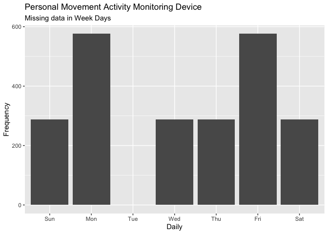

```r
g3 <- ggplot(data = dailydf, aes(Daily))

g3 + geom_bar(aes(weight = ISNA_Count))+
        labs(title="Personal Movement Activity Monitoring Device",
         subtitle="Missing data in Week Days",
         x="Daily",
         y="Frequency")
```

3. Create a new dataset that is equal to the original dataset but with the missing data filled in.

```r
# load these library at these section because it affects lubridate labels
# and abbr
library(mice)
library(missForest)
library(VIM)
```

Using aggr function to plot NA.

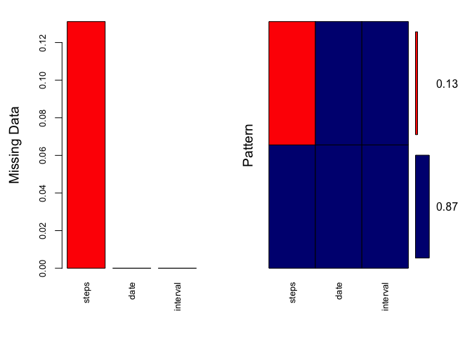

```
##
##  Variables sorted by number of missings:
##  Variable     Count
##     steps 0.1311475
##      date 0.0000000
##  interval 0.0000000
```

```r
aggr(maindf, col=c('navyblue', 'red'),
     numbers=TRUE, sortVars=TRUE,
     labels=names(maindf), cex.axis=.8,
     gap=5, ylab=c("Missing Data", "Pattern"))
```

I’m using Predictive Mean Matching (PMM) model to impute the missing data. 1. m = number of multiple imputations. Default is 5 and I picked 3.  
2. maxit = A scalar giving the number of imputations. the default is 5 and I chose 50 3. Method = pmm 4. seed = set.seed

```r
imputed_maindf1 <- mice(maindf, m=3, maxit = 50,
                        method = 'pmm', seed = 420)
```

Summary of the Imputed Data.

```r
summary(imputed_maindf1)
```

```
## Class: mids
## Number of multiple imputations:  3
## Imputation methods:
##    steps     date interval
##    "pmm"       ""       ""
## PredictorMatrix:
##          steps date interval
## steps        0    1        1
## date         1    0        1
## interval     1    1        0
```

Multiple imputations (m=3)

```r
head(imputed_maindf1$imp$steps)
```

```
##   1  2  3
## 1 0 47 47
## 2 0  0  0
## 3 0  0  0
## 4 0  0  0
## 5 0  0  0
## 6 0  0  0
```

Picking a model from m = 3 to impute the data.

```r
complete_Maindf1 <- complete(imputed_maindf1, 1)

summary(complete_Maindf1)
```

```
##      steps             date               interval
##  Min.   :  0.00   Min.   :2012-10-01   Min.   :   0.0
##  1st Qu.:  0.00   1st Qu.:2012-10-16   1st Qu.: 588.8
##  Median :  0.00   Median :2012-10-31   Median :1177.5
##  Mean   : 37.07   Mean   :2012-10-31   Mean   :1177.5
##  3rd Qu.: 12.00   3rd Qu.:2012-11-15   3rd Qu.:1766.2
##  Max.   :806.00   Max.   :2012-11-30   Max.   :2355.0
```

4. Make a histogram of the total number of steps taken each day and Calculate and report the mean and median total number of steps taken per day. Do these values differ from the estimates from the first part of the assignment? What is the impact of imputing missing data on the estimates of the total daily number of steps?

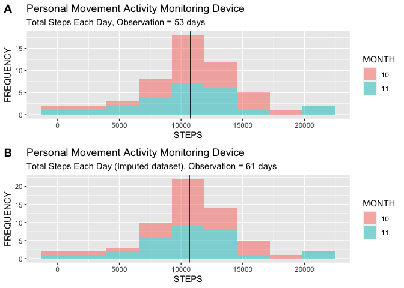

```r
CompleteMeanTotal <- complete_Maindf1 %>% group_by(date) %>%  summarize(Steps = sum(steps)) %>% mutate(m=month(date))

g4<-ggplot(data = CompleteMeanTotal, aes(x=Steps,fill=factor(m)))

gg4<-g4+geom_histogram(bins = 9, alpha=.5)+geom_vline(
                xintercept = mean(CompleteMeanTotal$Steps))+
        labs(title="Personal Movement Activity Monitoring Device",
                subtitle="Total Steps Each Day (Imputed dataset), Observation = 61 days",
                x="STEPS",
                y="FREQUENCY",
                fill="MONTH")

library(cowplot)

plot_grid(gg1, gg4, nrow = 2, labels = "AUTO")
```

Calculating the steps mean and median.

```r
CompleteTotal <-
    complete_Maindf1 %>% drop_na() %>% group_by(date) %>%
    summarize(Steps = sum(steps)) %>% mutate(m =month(date))

CompleteMeanMed <-
    CompleteTotal %>% summarize(
      Obs = length(date),
      SumofSteps = sum(Steps),
      StepsMean = mean(Steps),
      StepsMedian = median(Steps)
  )

GTCompleteMeanMed <- CompleteMeanMed %>% gt::gt() %>% data_color(
    columns = vars(Obs, SumofSteps, StepsMean, StepsMedian),
      colors = c("yellow")
) %>%
    tab_header(title = "Step Mean and Median Summary (No missing data",
               subtitle = glue("{start_date} to {end_date}"))


GTCompleteMeanMed
```

Step Mean and Median Summary (No missing data

2012-10-01 to 2012-11-30

| Obs | SumofSteps | StepsMean | StepsMedian |
| --- | --- | --- | --- |
| 61 | 651215 | 10675.66 | 10571 |

Original data set with NA remove.

```r
GTMeanTotal
```

Step Mean and Median Summary

2012-10-01 to 2012-11-30

| Obs | SumofSteps | StepsMean | StepsMedian |
| --- | --- | --- | --- |
| 53 | 570608 | 10766.19 | 10765 |

Comparison formula:

```r
NewSteps <- CompleteMeanMed$SumofSteps - StepsMeanMed$SumofSteps
NewMean <- CompleteMeanMed$StepsMean - StepsMeanMed$StepsMean
NewMed <- CompleteMeanMed$StepsMedian - StepsMeanMed$StepsMedian
NewSteps
```

```
## [1] 80607
```

```r
NewMean
```

```
## [1] -90.53294
```

```r
NewMed
```

```
## [1] -194
```